# Assignment 6: Apply NB

1. Minimum data points need to be considered for people having 4GB RAM is **50k** and for 8GB RAM is **100k**
2. When you are using ramdomsearchcv or gridsearchcv you need not split the data into X_train,X_cv,X_test. As the above methods use kfold. The model will learn better if train data is more so splitting to X_train,X_test will suffice.
3. If you are writing for loops to tune your model then you need split the data into X_train,X_cv,X_test.
4. While splitting the data explore stratify parameter.
5. **Apply Multinomial NB on these feature sets**
- Features that need to be considered

**essay**

while encoding essay, try to experiment with the max_features and n_grams parameter of vectorizers and see if it increases AUC score.

**categorical features**

- teacher_prefix

- project_grade_category

- school_state

- clean_categories

- clean_subcategories

**numerical features**

- price

- teacher_number_of_previously_posted_projects

while encoding the numerical features check [this](https://imgur.com/ldZA1zg) and [this](https://ac-classroom-production.s3.amazonaws.com/public/COMMENT/Annotation_2020-05-21_225912_0lyZzN8.jpg)

- Set 1: categorical, numerical features + preprocessed_eassay (BOW)
- Set 2: categorical, numerical features + preprocessed_eassay (TFIDF)
6. **The hyper paramter tuning(find best alpha:smoothing parameter)**
   - Consider alpha values in range: 10^-5 to 10^2 like [0.00001,0.0005, 0.0001,0.005,0.001,0.05,0.01,0.1,0.5,1,5,10,50,100]
   - Explore class_prior = [0.5, 0.5] parameter which can be present in MultinomialNB function(go through [this](https://scikit-learn.org/stable/modules/generated/sklearn.naive_bayes.MultinomialNB.html) ) then check how results might change.
   - Find the best hyper parameter which will give the maximum [AUC](https://www.appliedaicourse.com/course/applied-ai-course-online/lessons/receiver-operating-characteristic-curve-roc-curve-and-auc-1/) value
   - For hyper parameter tuning using k-fold cross validation(use GridsearchCV or RandomsearchCV)/simple cross validation data (write for loop to iterate over hyper parameter values)
   - You need to plot the performance of model both on train data and cross validation data for each hyper parameter, like shown in the figure

[figure not shown]

     -while plotting take log(alpha) on your X-axis so that it will be more readable
   - Once after you found the best hyper parameter, you need to train your model with it, and find the AUC on test data and plot the ROC curve on both train and test.

[figure not shown]

   - Along with plotting ROC curve, you need to print the [confusion matrix](https://www.appliedaicourse.com/course/applied-ai-course-online/lessons/confusion-matrix-tpr-fpr-fnr-tnr-1/) with predicted and original labels of test data points

[figure not shown]

     -plot the confusion matrix in heatmaps, while plotting the confusion matrix go through the [link](https://stackoverflow.com/questions/61748441/how-to-fix-the-values-displayed-in-a-confusion-matrix-in-exponential-form-to-nor)
7. find the top 20 features from either from feature Set 1 or feature Set 2 using values of `feature_log_prob_ ` parameter of `MultinomialNB` (https://scikit-learn.org/stable/modules/generated/sklearn.naive_bayes.MultinomialNB.html) and print **BOTH** positive as well as negative corresponding feature names.

   - go through the [link](https://imgur.com/mWvE7gj)
8. You need to summarize the results at the end of the notebook, summarize it in the table format

[figure not shown]

# 2. Naive Bayes

## 1.1 Loading Data

```python
import pandas
data = pandas.read_csv('preprocessed_data.csv')
```

```python
data.head(5)
```

|  | school_state | teacher_prefix | project_grade_category | teacher_number_of_previously_posted_projects | project_is_approved | clean_categories | clean_subcategories | essay | price |
| --- | --- | --- | --- | --- | --- | --- | --- | --- | --- |
| 0 | ca | mrs | grades_prek_2 | 53 | 1 | math_science | appliedsciences health_lifescience | i fortunate enough use fairy tale stem kits cl... | 725.05 |
| 1 | ut | ms | grades_3_5 | 4 | 1 | specialneeds | specialneeds | imagine 8 9 years old you third grade classroo... | 213.03 |
| 2 | ca | mrs | grades_prek_2 | 10 | 1 | literacy_language | literacy | having class 24 students comes diverse learner... | 329.00 |
| 3 | ga | mrs | grades_prek_2 | 2 | 1 | appliedlearning | earlydevelopment | i recently read article giving students choice... | 481.04 |
| 4 | wa | mrs | grades_3_5 | 2 | 1 | literacy_language | literacy | my students crave challenge eat obstacles brea... | 17.74 |

```python
y = data['project_is_approved'].values
X = data.drop(['project_is_approved'], axis=1)
X.head(5)
```

|  | school_state | teacher_prefix | project_grade_category | teacher_number_of_previously_posted_projects | clean_categories | clean_subcategories | essay | price |
| --- | --- | --- | --- | --- | --- | --- | --- | --- |
| 0 | ca | mrs | grades_prek_2 | 53 | math_science | appliedsciences health_lifescience | i fortunate enough use fairy tale stem kits cl... | 725.05 |
| 1 | ut | ms | grades_3_5 | 4 | specialneeds | specialneeds | imagine 8 9 years old you third grade classroo... | 213.03 |
| 2 | ca | mrs | grades_prek_2 | 10 | literacy_language | literacy | having class 24 students comes diverse learner... | 329.00 |
| 3 | ga | mrs | grades_prek_2 | 2 | appliedlearning | earlydevelopment | i recently read article giving students choice... | 481.04 |
| 4 | wa | mrs | grades_3_5 | 2 | literacy_language | literacy | my students crave challenge eat obstacles brea... | 17.74 |

## 1.2 Splitting data into Train and cross validation(or test): Stratified Sampling

```python
# please write all the code with proper documentation, and proper titles for each subsection
# go through documentations and blogs before you start coding
# first figure out what to do, and then think about how to do.
# reading and understanding error messages will be very much helpfull in debugging your code
# when you plot any graph make sure you use
    # a. Title, that describes your plot, this will be very helpful to the reader
    # b. Legends if needed
    # c. X-axis label
    # d. Y-axis label
```

```python
import numpy as np
from sklearn.model_selection import train_test_split
X_train, X_test, y_train, y_test = train_test_split(X, y, test_size=0.33, stratify=y)
print(len(X_train),len(X_test))
```

```
73196 36052
```

## 1.3 Make Data Model Ready: encoding eassay, and project_title

```python
essay_train= X_train['essay'].values
essay_train.shape
```

```
(73196,)
```

```python
essay_test=X_test['essay'].values
essay_test.shape
```

```
(36052,)
```

```python
from sklearn.feature_extraction.text import CountVectorizer
vec = CountVectorizer(min_df=10)
essay_train_bow=vec.fit_transform(essay_train)
essay_test_bow= vec.transform(essay_test)
```

```python
print(essay_train_bow.shape,essay_test_bow.shape)
```

```
(73196, 14279) (36052, 14279)
```

```python
bow_names=vec.get_feature_names()
print("Number of unique words appearing more than 10 times",len(bow_names))
```

```
Number of unique words appearing more than 10 times 14279
```

```python
from sklearn.feature_extraction.text import TfidfVectorizer
vec2 = TfidfVectorizer(min_df=10)
train_essay_tfidf= vec2.fit_transform(essay_train)
test_essay_tfidf= vec2.transform(essay_test)
```

```python
print(train_essay_tfidf.shape,test_essay_tfidf.shape)
```

```
(73196, 14279) (36052, 14279)
```

## 1.4 Make Data Model Ready: encoding numerical, categorical features

```python
# please write all the code with proper documentation, and proper titles for each subsection
# go through documentations and blogs before you start coding
# first figure out what to do, and then think about how to do.
# reading and understanding error messages will be very much helpfull in debugging your code
# make sure you featurize train and test data separatly

# when you plot any graph make sure you use
    # a. Title, that describes your plot, this will be very helpful to the reader
    # b. Legends if needed
    # c. X-axis label
    # d. Y-axis label
```

```python
#school state feature
ohe = CountVectorizer()
train_state = ohe.fit_transform(X_train['school_state'].values)
test_state = ohe.transform(X_test['school_state'].values)
```

```python
print(train_state.shape, test_state.shape)
print("\n", ohe.get_feature_names())

states=  ohe.get_feature_names()
```

```
(73196, 51) (36052, 51)

 ['ak', 'al', 'ar', 'az', 'ca', 'co', 'ct', 'dc', 'de', 'fl', 'ga', 'hi', 'ia', 'id', 'il', 'in', 'ks', 'ky', 'la', 'ma', 'md', 'me', 'mi', 'mn', 'mo', 'ms', 'mt', 'nc', 'nd', 'ne', 'nh', 'nj', 'nm', 'nv', 'ny', 'oh', 'ok', 'or', 'pa', 'ri', 'sc', 'sd', 'tn', 'tx', 'ut', 'va', 'vt', 'wa', 'wi', 'wv'…
```

```python
#teacher prefix feature

train_teacher = ohe.fit_transform(X_train['teacher_prefix'].values)
test_teacher = ohe.transform(X_test['teacher_prefix'].values)

teacher_prefix= ohe.get_feature_names()
print(train_teacher.shape, test_teacher.shape)
print("\n",  ohe.get_feature_names())
```

```
(73196, 5) (36052, 5)

 ['dr', 'mr', 'mrs', 'ms', 'teacher']
```

```python
# grade feature vectorization

train_grade = ohe.fit_transform(X_train['project_grade_category'].values)
test_grade = ohe.transform(X_test['project_grade_category'].values)

grades= ohe.get_feature_names()

print(train_grade.shape, test_grade.shape)
print("\n",  ohe.get_feature_names())
```

```
(73196, 4) (36052, 4)

 ['grades_3_5', 'grades_6_8', 'grades_9_12', 'grades_prek_2']
```

```python
# category

train_category =  ohe.fit_transform(X_train['clean_categories'].values)
test_category =  ohe.transform(X_test['clean_categories'].values)

category =  ohe.get_feature_names()

print(train_category.shape, test_category.shape)
print("\n",  ohe.get_feature_names())
```

```
(73196, 9) (36052, 9)

 ['appliedlearning', 'care_hunger', 'health_sports', 'history_civics', 'literacy_language', 'math_science', 'music_arts', 'specialneeds', 'warmth']
```

```python
#clean_subcategories

train_subcategory =  ohe.fit_transform(X_train['clean_subcategories'].values)
test_subcategory =  ohe.transform(X_test['clean_subcategories'].values)

subcategory =  ohe.get_feature_names()

print(train_subcategory.shape, test_subcategory.shape)
print("\n",  ohe.get_feature_names())
```

```
(73196, 30) (36052, 30)

 ['appliedsciences', 'care_hunger', 'charactereducation', 'civics_government', 'college_careerprep', 'communityservice', 'earlydevelopment', 'economics', 'environmentalscience', 'esl', 'extracurricular', 'financialliteracy', 'foreignlanguages', 'gym_fitness', 'health_lifescience', 'health_wellness',…
```

```python
#numerical features
#teacher_number_of_previously_posted_projects

from sklearn.preprocessing import Normalizer
norm = Normalizer()
norm.fit(X_train['teacher_number_of_previously_posted_projects'].values.reshape(1,-1))
train_previous_posted = norm.transform(X_train['teacher_number_of_previously_posted_projects'].values.reshape(1,-1))
test_previous_posted = norm.transform(X_test['teacher_number_of_previously_posted_projects'].values.reshape(1,-1))

print(train_previous_posted.shape, test_previous_posted.shape)
```

```
(1, 73196) (1, 36052)
```

```python
train_previous_posted=np.transpose(train_previous_posted)
test_previous_posted= np.transpose(test_previous_posted)
```

```python
#price feature

norm.fit(X_train['price'].values.reshape(-1,1))

train_price = norm.transform(X_train['price'].values.reshape(1,-1))
test_price = norm.transform(X_test['price'].values.reshape(1,-1))

print(train_price.shape, test_price.shape)
```

```
(1, 73196) (1, 36052)
```

```python
train_price=np.transpose(train_price)
test_price= np.transpose(test_price)
```

```python
from scipy.sparse import hstack

x_tr_bow= hstack((train_state, train_teacher, train_grade, train_previous_posted, train_category, train_subcategory, essay_train_bow, train_price)).tocsr()
x_te_bow= hstack((test_state, test_teacher, test_grade, test_previous_posted, test_category, test_subcategory,essay_test_bow, test_price)).tocsr()
```

```python
print(x_tr_bow.shape, x_te_bow.shape)
```

```
(73196, 14380) (36052, 14380)
```

```python
x_tr_tfidf= hstack((train_state, train_teacher, train_grade, train_previous_posted, train_category, train_subcategory,train_essay_tfidf, train_price)).tocsr()
x_te_tfidf= hstack((test_state, test_teacher, test_grade, test_previous_posted, test_category, test_subcategory,test_essay_tfidf, test_price)).tocsr()
```

## 1.5 Appling NB on different kind of featurization as mentioned in the instructions

Apply NB on different kind of featurization as mentioned in the instructions  
For Every model that you work on make sure you do the step 2 and step 3 of instrucations

```python
# please write all the code with proper documentation, and proper titles for each subsection
# go through documentations and blogs before you start coding
# first figure out what to do, and then think about how to do.
# reading and understanding error messages will be very much helpfull in debugging your code
# when you plot any graph make sure you use
    # a. Title, that describes your plot, this will be very helpful to the reader
    # b. Legends if needed
    # c. X-axis label
    # d. Y-axis label
```

```python
from scipy.stats import randint as sp_randint
from sklearn.model_selection import RandomizedSearchCV
from sklearn.naive_bayes import MultinomialNB
from sklearn.metrics import roc_auc_score
import matplotlib.pyplot as plt
import pandas as pd
import warnings
warnings.filterwarnings("ignore")
```

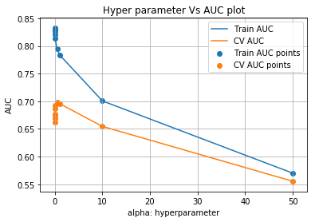

|  | mean_fit_time | std_fit_time | mean_score_time | std_score_time | param_alpha | params | split0_test_score | split1_test_score | split2_test_score | mean_test_score | std_test_score | rank_test_score | split0_train_score | split1_train_score | split2_train_score | mean_train_score | std_train_score |
| --- | --- | --- | --- | --- | --- | --- | --- | --- | --- | --- | --- | --- | --- | --- | --- | --- | --- |
| 5 | 0.109707 | 0.012720 | 0.020280 | 0.002050 | 1e-05 | {'alpha': 1e-05} | 0.659961 | 0.665072 | 0.659789 | 0.661607 | 0.002451 | 8 | 0.833302 | 0.833645 | 0.829919 | 0.832289 | 0.001682 |
| 8 | 0.096076 | 0.002049 | 0.017287 | 0.000940 | 0.0001 | {'alpha': 0.0001} | 0.667037 | 0.672764 | 0.666616 | 0.668806 | 0.002804 | 7 | 0.831447 | 0.831591 | 0.827732 | 0.830257 | 0.001787 |
| 6 | 0.102060 | 0.006632 | 0.017620 | 0.000941 | 0.0005 | {'alpha': 0.0005} | 0.672812 | 0.679115 | 0.672070 | 0.674665 | 0.003161 | 6 | 0.829347 | 0.829274 | 0.825322 | 0.827981 | 0.001880 |
| 9 | 0.098403 | 0.007992 | 0.016623 | 0.000470 | 0.001 | {'alpha': 0.001} | 0.675462 | 0.682000 | 0.674602 | 0.677354 | 0.003304 | 5 | 0.828162 | 0.827961 | 0.823981 | 0.826701 | 0.001925 |
| 3 | 0.100398 | 0.001243 | 0.017952 | 0.000814 | 0.01 | {'alpha': 0.01} | 0.684676 | 0.691981 | 0.683397 | 0.686684 | 0.003781 | 4 | 0.822494 | 0.821676 | 0.817660 | 0.820610 | 0.002113 |

```python
#for eassy using bow
nb = MultinomialNB()
parameters = {'alpha':[0.00001,0.0005, 0.0001,0.005,0.001,0.05,0.01,0.1,0.5,1,5,10,50,100]}
clf = RandomizedSearchCV(nb, parameters, cv=3, scoring='roc_auc', n_jobs=-1)

clf.fit(x_tr_bow, y_train)

results = pd.DataFrame.from_dict(clf.cv_results_)
results = results.sort_values(['param_alpha'])

train_auc= results['mean_train_score']
train_auc_std= results['std_train_score']

cv_auc = results['mean_test_score']
cv_auc_std= results['std_test_score']

K =  results['param_alpha']

plt.plot(K, train_auc, label='Train AUC')

plt.plot(K, cv_auc, label='CV AUC')

plt.scatter(K, train_auc, label='Train AUC points')
plt.scatter(K, cv_auc, label='CV AUC points')

plt.legend()
plt.xlabel("alpha: hyperparameter")
plt.ylabel("AUC")
plt.title("Hyper parameter Vs AUC plot")
plt.grid()
plt.show()

results.head()
```

```python
best_alpha_bow= 1.0
```

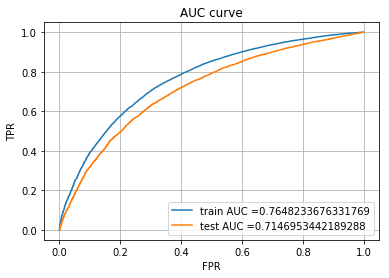

```python
#reference notebook
from sklearn.metrics import roc_curve, auc

nb1 = MultinomialNB(alpha=best_alpha_bow)
nb1.fit(x_tr_bow, y_train)

yp_train= nb1.predict_proba(x_tr_bow)[:,1]
yp_test= nb1.predict_proba(x_te_bow)[:,1]
#print(yp_train.shape)

train_fpr, train_tpr, tr_thresholds = roc_curve(y_train, yp_train)
test_fpr, test_tpr, te_thresholds = roc_curve(y_test, yp_test)

plt.plot(train_fpr, train_tpr, label="train AUC ="+str(auc(train_fpr, train_tpr)))
plt.plot(test_fpr, test_tpr, label="test AUC ="+str(auc(test_fpr, test_tpr)))

train_bow_auc=auc(train_fpr, train_tpr)
test_bow_auc=auc(test_fpr, test_tpr)

plt.legend()
plt.xlabel("FPR")
plt.ylabel("TPR")
plt.title("AUC curve")
plt.grid()
plt.show()
```

```python
#confusion matrix
from sklearn.metrics import confusion_matrix

print("Confusion matrix for test data using bow \n",confusion_matrix(y_test, nb1.predict(x_te_bow)))
```

```
Confusion matrix for test data using bow
 [[ 2806  2653]
 [ 6659 23934]]
```

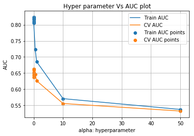

|  | mean_fit_time | std_fit_time | mean_score_time | std_score_time | param_alpha | params | split0_test_score | split1_test_score | split2_test_score | mean_test_score | std_test_score | rank_test_score | split0_train_score | split1_train_score | split2_train_score | mean_train_score | std_train_score |
| --- | --- | --- | --- | --- | --- | --- | --- | --- | --- | --- | --- | --- | --- | --- | --- | --- | --- |
| 3 | 0.079011 | 0.011688 | 0.017832 | 0.001765 | 1e-05 | {'alpha': 1e-05} | 0.634976 | 0.640706 | 0.633035 | 0.636239 | 0.003257 | 7 | 0.825198 | 0.826783 | 0.818630 | 0.823537 | 0.003530 |
| 9 | 0.084111 | 0.008491 | 0.016066 | 0.000628 | 0.0001 | {'alpha': 0.0001} | 0.642011 | 0.648053 | 0.638960 | 0.643008 | 0.003778 | 6 | 0.822915 | 0.824247 | 0.815744 | 0.820969 | 0.003734 |
| 6 | 0.070791 | 0.000804 | 0.015966 | 0.000012 | 0.0005 | {'alpha': 0.0005} | 0.648454 | 0.655062 | 0.644271 | 0.649262 | 0.004443 | 4 | 0.820059 | 0.821076 | 0.812262 | 0.817799 | 0.003937 |
| 2 | 0.087765 | 0.016347 | 0.018618 | 0.002351 | 0.001 | {'alpha': 0.001} | 0.651578 | 0.658498 | 0.646897 | 0.652324 | 0.004765 | 3 | 0.818321 | 0.819147 | 0.810189 | 0.815886 | 0.004042 |
| 1 | 0.075133 | 0.001695 | 0.016955 | 0.001410 | 0.005 | {'alpha': 0.005} | 0.659209 | 0.666858 | 0.653390 | 0.659819 | 0.005515 | 2 | 0.812449 | 0.812618 | 0.803354 | 0.809474 | 0.004328 |

```python
# for tfidf feature

nb = MultinomialNB()
parameters = {'alpha':[0.00001,0.0005, 0.0001,0.005,0.001,0.05,0.01,0.1,0.5,1,5,10,50,100]}
clf = RandomizedSearchCV(nb, parameters, cv=3, scoring='roc_auc')

clf.fit(x_tr_tfidf, y_train)

results = pd.DataFrame.from_dict(clf.cv_results_)
results = results.sort_values(['param_alpha'])

train_auc= results['mean_train_score']
train_auc_std= results['std_train_score']

cv_auc = results['mean_test_score']
cv_auc_std= results['std_test_score']

K =  results['param_alpha']

plt.plot(K, train_auc, label='Train AUC')

plt.plot(K, cv_auc, label='CV AUC')

plt.scatter(K, train_auc, label='Train AUC points')
plt.scatter(K, cv_auc, label='CV AUC points')

plt.legend()
plt.xlabel("alpha: hyperparameter")
plt.ylabel("AUC")
plt.title("Hyper parameter Vs AUC plot")
plt.grid()
plt.show()

results.head()
```

```python
best_alpha_tfidf= 1
```

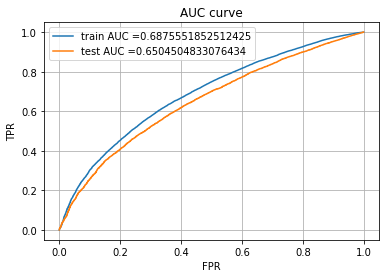

```python
nb = MultinomialNB(alpha=best_alpha_tfidf)
nb.fit(x_tr_tfidf, y_train)

yp_train= nb.predict_proba(x_tr_tfidf)[:,1]
yp_test= nb.predict_proba(x_te_tfidf)[:,1]
#print(yp_train.shape)

train_fpr, train_tpr, tr_thresholds = roc_curve(y_train, yp_train)
test_fpr, test_tpr, te_thresholds = roc_curve(y_test, yp_test)

plt.plot(train_fpr, train_tpr, label="train AUC ="+str(auc(train_fpr, train_tpr)))
plt.plot(test_fpr, test_tpr, label="test AUC ="+str(auc(test_fpr, test_tpr)))

train_tfidf_auc=auc(train_fpr, train_tpr)
test_tfidf_auc=auc(test_fpr, test_tpr)

plt.legend()
plt.xlabel("FPR")
plt.ylabel("TPR")
plt.title("AUC curve")
plt.grid()
plt.show()
```

```python
print("Confusion matrix for test data using bow \n",confusion_matrix(y_test, nb.predict(x_te_tfidf)))
```

```
Confusion matrix for test data using bow
 [[   34  5425]
 [   63 30530]]
```

# 3. Summary

as mentioned in the step 5 of instructions

```python
fe=[]
#print(len(states))
for ele in states:
    fe.append(ele)

#print(len(teacher_prefix))
for ele in teacher_prefix:
    fe.append(ele)
'''fe.append(states)
fe.append(teacher_prefix)
fe.append(grades)'''

#print(len(grades))
for ele in grades:
    fe.append(ele)

fe.append('posted projects')

#print(len(category))
for ele in category:
    fe.append(ele)

#print(len(subcategory))
for ele in subcategory:
    fe.append(ele)

#print(len(bow_names))
for ele in bow_names:
    fe.append(ele)

'''fe.append(category)
fe.append(subcategory)
fe.append(bow_names)'''

fe.append('price')

print(len(fe))
```

```
14380
```

```python
negative_fe= nb1.feature_log_prob_[0]
positive_fe= nb1.feature_log_prob_[1]
```

```python
negative_fe[0:20]
```

```
array([-10.66273578,  -9.12417221,  -9.5128302 ,  -8.85358457,
        -7.00390868,  -9.47200821,  -9.30988936, -10.03764207,
       -11.30458967,  -7.78709183,  -8.26245102, -10.36849631,
       -10.0518267 ,  -9.95651652,  -8.22497591,  -8.71682564,
       -10.08081424,  -9.57293413,  -8.68719384,  -8.85358457])
```

```python
neg=np.argsort(negative_fe)
pos=np.argsort(positive_fe)
```

```python
neg_20=neg[-1:-21:-1]
pos_20=pos[-1:-21:-1]
```

```python
print(neg_20,"\n", pos_20)
```

```
[12382 11253  7458  8447  2488  7454  8667 12912  6134 12872  8471  7888
 13983  8528 14223  2652  7729 10373   359 11707]
 [12382 11253  8447  7458  2488 12872 12912  8667  7454  6134  7888  8471
 13983 10373  8528 14223 13655  7729  3407   359]
```

```python
print("most important feature for class 1\n")
for i in pos_20:
    print(fe[i])

print("\n\nmost important feature for class 0\n")
for j in neg_20:
    print(fe[j])
```

```
most important feature for class 1

students
school
my
learning
classroom
the
they
not
learn
help
many
nannan
we
reading
need
work
use
love
day
able


most important feature for class 0

students
school
learning
my
classroom
learn
not
they
help
the
nannan
many
we
need
work
come
love
reading
able
skills
```

```python
from prettytable import PrettyTable

#https://www.geeksforgeeks.org/how-to-make-a-table-in-python/
myTable = PrettyTable(["model", "Alpha", "AUC train", "AUC test"])

myTable.add_row(["BOW NB", best_alpha_bow,  train_bow_auc,test_bow_auc])
myTable.add_row(["TFIDF NB", best_alpha_tfidf, train_tfidf_auc, test_tfidf_auc])

print(myTable)
```

```
+----------+-------+--------------------+--------------------+
|  model   | Alpha |     AUC train      |      AUC test      |
+----------+-------+--------------------+--------------------+
|  BOW NB  |  1.0  | 0.7648233676331769 | 0.7146953442189288 |
| TFIDF NB |   1   | 0.6875551852512425 | 0.6504504833076434 |
+----------+-------+--------------------+--------------------+
```